# CEMA INTERNSHIP TASK

ADERO WALTER OBILA

2023-07-19

```r
rm(list=ls())
```

```r
library(dplyr)
library(ggplot2)
library(tidyverse)
library(data.table)
library(janitor)
library(lubridate)
```

```r
#Importing the data
library(readr)
data <- read_csv("C:/Users/Admin/Desktop/CEMA/cema_internship_task_2023.csv")
head(data)
```

```
## # A tibble: 6 × 11
##   period county      `Total Dewormed` `Acute Malnutrition` `stunted 6-23 months`
##   <chr>  <chr>                  <dbl>                <dbl>                 <dbl>
## 1 Jan-23 Baringo Co…             3659                    8                   471
## 2 Jan-23 Bomet Coun…             1580                   NA                     1
## 3 Jan-23 Bungoma Co…             6590                   24                    98
## 4 Jan-23 Busia Coun…             7564                   NA                   396
## 5 Jan-23 Elgeyo Mar…             1407                   NA                    92
## 6 Jan-23 Embu County             3241                   72                   326
## # ℹ 6 more variables: `stunted 0-<6 months` <dbl>,
## #   `stunted 24-59 months` <dbl>, `diarrhoea cases` <dbl>,
## #   `Underweight 0-<6 months` <dbl>, `Underweight 6-23 months` <dbl>,
## #   `Underweight 24-59 Months` <dbl>
```

# Exploratory Data Analysis

## Structure of the data

```r
str(data)
```

```
## spc_tbl_ [1,410 × 11] (S3: spec_tbl_df/tbl_df/tbl/data.frame)
##  $ period                  : chr [1:1410] "Jan-23" "Jan-23" "Jan-23" "Jan-23" ...
##  $ county                  : chr [1:1410] "Baringo County" "Bomet County" "Bungoma County" "Busia County" ...
##  $ Total Dewormed          : num [1:1410] 3659 1580 6590 7564 1407 ...
##  $ Acute Malnutrition      : num [1:1410] 8 NA 24 NA NA 72 250 9 26 104 ...
##  $ stunted 6-23 months     : num [1:1410] 471 1 98 396 92 326 40 209 51 319 ...
##  $ stunted 0-<6 months     : num [1:1410] 34 3 154 143 71 86 13 87 6 102 ...
##  $ stunted 24-59 months    : num [1:1410] 380 NA 23 111 5 24 99 58 50 155 ...
##  $ diarrhoea cases         : num [1:1410] 2620 1984 4576 2239 2739 ...
##  $ Underweight 0-<6 months : num [1:1410] 85 41 231 251 57 141 223 140 13 139 ...
##  $ Underweight 6-23 months : num [1:1410] 739 86 315 608 104 ...
##  $ Underweight 24-59 Months: num [1:1410] 731 16 120 125 21 ...
##  - attr(*, "spec")=
##   .. cols(
##   ..   period = col_character(),
##   ..   county = col_character(),
##   ..   `Total Dewormed` = col_double(),
##   ..   `Acute Malnutrition` = col_double(),
##   ..   `stunted 6-23 months` = col_double(),
##   ..   `stunted 0-<6 months` = col_double(),
##   ..   `stunted 24-59 months` = col_double(),
##   ..   `diarrhoea cases` = col_double(),
##   ..   `Underweight 0-<6 months` = col_double(),
##   ..   `Underweight 6-23 months` = col_double(),
##   ..   `Underweight 24-59 Months` = col_double()
##   .. )
##  - attr(*, "problems")=<externalptr>
```

The dataset consists of 11 variables(columns), and 1410 instances(rows). The variables are a mixture of numeric and character variables. The character variables are period and county, while all the remaininng variables are numeric variables.

## Checking for duplicated values

```r
#Checking for duplicate values
unique(duplicated(data))
```

```
## [1] FALSE
```

The data contains no duplicated values.

## Missing observations

```r
sum(is.na(data))
```

```
## [1] 399
```

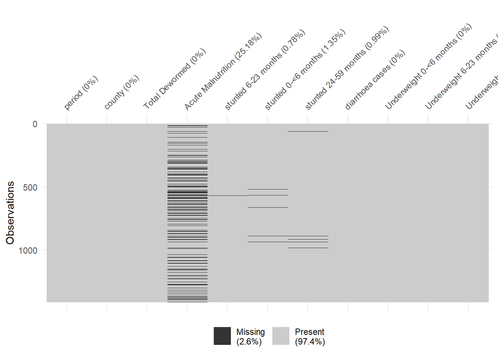

```r
library(naniar)
vis_miss(data)
```

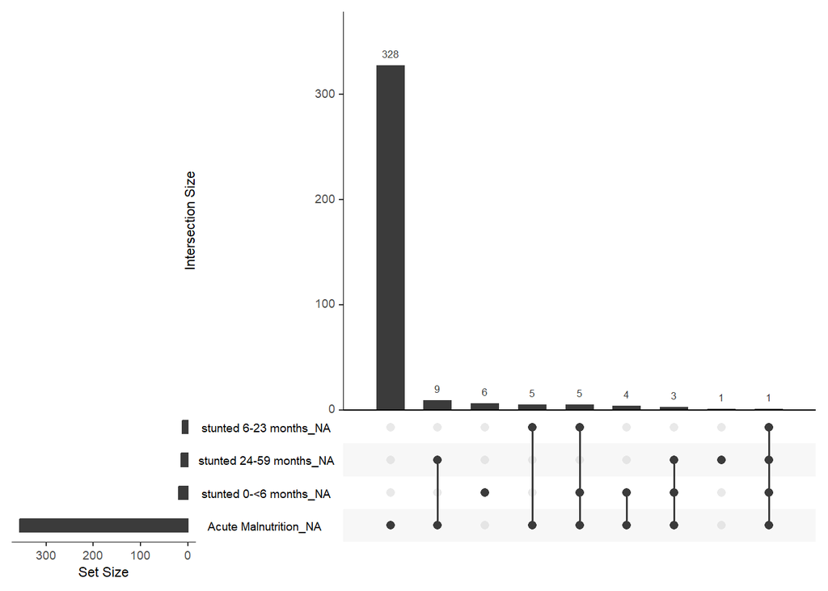

```r
library(UpSetR)
gg_miss_upset(data)
```

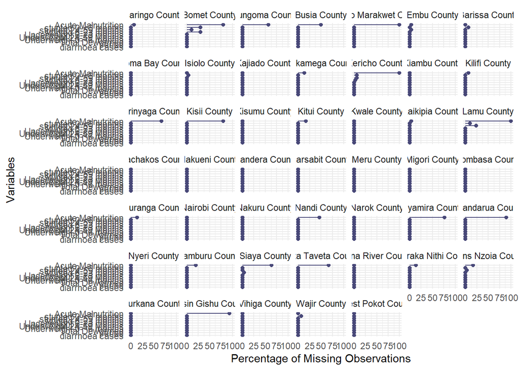

```r
gg_miss_var(data, show_pct = TRUE, facet = county)+labs(y="Percentage of Missing Observations")
```

## Summary of the numerical Variables

```r
summary(data[,-c(1,2)])
```

```
##  Total Dewormed   Acute Malnutrition stunted 6-23 months stunted 0-<6 months
##  Min.   :    97   Min.   :   1.0     Min.   :   1.0      Min.   :   1.0
##  1st Qu.:  2454   1st Qu.:  15.0     1st Qu.:  69.5      1st Qu.:  36.5
##  Median :  4564   Median :  39.0     Median : 159.0      Median :  84.0
##  Mean   : 11458   Mean   : 125.4     Mean   : 280.2      Mean   : 139.8
##  3rd Qu.:  8222   3rd Qu.: 143.5     3rd Qu.: 328.5      3rd Qu.: 157.0
##  Max.   :392800   Max.   :4123.0     Max.   :4398.0      Max.   :7900.0
##                   NA's   :355        NA's   :11          NA's   :19
##  stunted 24-59 months diarrhoea cases Underweight 0-<6 months
##  Min.   :   1.0       Min.   :  198   Min.   :   6.0
##  1st Qu.:  22.0       1st Qu.: 1464   1st Qu.:  87.0
##  Median :  50.0       Median : 2158   Median : 162.5
##  Mean   : 110.8       Mean   : 2813   Mean   : 223.5
##  3rd Qu.: 114.2       3rd Qu.: 3335   3rd Qu.: 272.8
##  Max.   :3169.0       Max.   :15795   Max.   :1937.0
##  NA's   :14
##  Underweight 6-23 months Underweight 24-59 Months
##  Min.   :  16.0          Min.   :   1.00
##  1st Qu.: 249.0          1st Qu.:  51.25
##  Median : 456.0          Median : 120.50
##  Mean   : 652.3          Mean   : 305.74
##  3rd Qu.: 791.8          3rd Qu.: 311.00
##  Max.   :5348.0          Max.   :4680.00
##
```

Here, we see some summary statiscitcs for the numerical variables in the data. The summary statistics provided are minimum, 1st quartile, median, mean, 3rd quartile and maximum. Taking for instance the “Total Dewormed” variable, we see that the minimum entry is 97, the meadian is 4564, the mean 11458 and the maximum entry is 392800.

## Exploring the correlations between the numerical variables

```r
corl<-cor(na.omit(data[,-c(1,2)]))
corl
```

```
##                          Total Dewormed Acute Malnutrition stunted 6-23 months
## Total Dewormed               1.00000000         0.08014465          0.30946499
## Acute Malnutrition           0.08014465         1.00000000          0.09823035
## stunted 6-23 months          0.30946499         0.09823035          1.00000000
## stunted 0-<6 months          0.46039717         0.07525906          0.55318434
## stunted 24-59 months         0.17500396         0.23739614          0.45381318
## diarrhoea cases              0.32314550         0.24506553          0.63748682
## Underweight 0-<6 months      0.34466060         0.13018643          0.69172928
## Underweight 6-23 months      0.34375231         0.30601721          0.80521446
## Underweight 24-59 Months     0.07584220         0.44006748          0.27855404
##                          stunted 0-<6 months stunted 24-59 months
## Total Dewormed                    0.46039717            0.1750040
## Acute Malnutrition                0.07525906            0.2373961
## stunted 6-23 months               0.55318434            0.4538132
## stunted 0-<6 months               1.00000000            0.2016231
## stunted 24-59 months              0.20162307            1.0000000
## diarrhoea cases                   0.46591258            0.3909895
## Underweight 0-<6 months           0.62900314            0.2305176
## Underweight 6-23 months           0.53242767            0.6110149
## Underweight 24-59 Months          0.07009893            0.7100677
##                          diarrhoea cases Underweight 0-<6 months
## Total Dewormed                 0.3231455              0.34466060
## Acute Malnutrition             0.2450655              0.13018643
## stunted 6-23 months            0.6374868              0.69172928
## stunted 0-<6 months            0.4659126              0.62900314
## stunted 24-59 months           0.3909895              0.23051760
## diarrhoea cases                1.0000000              0.66797376
## Underweight 0-<6 months        0.6679738              1.00000000
## Underweight 6-23 months        0.7290982              0.71959646
## Underweight 24-59 Months       0.3518845              0.06908767
##                          Underweight 6-23 months Underweight 24-59 Months
## Total Dewormed                         0.3437523               0.07584220
## Acute Malnutrition                     0.3060172               0.44006748
## stunted 6-23 months                    0.8052145               0.27855404
## stunted 0-<6 months                    0.5324277               0.07009893
## stunted 24-59 months                   0.6110149               0.71006767
## diarrhoea cases                        0.7290982               0.35188454
## Underweight 0-<6 months                0.7195965               0.06908767
## Underweight 6-23 months                1.0000000               0.55404504
## Underweight 24-59 Months               0.5540450               1.00000000
```

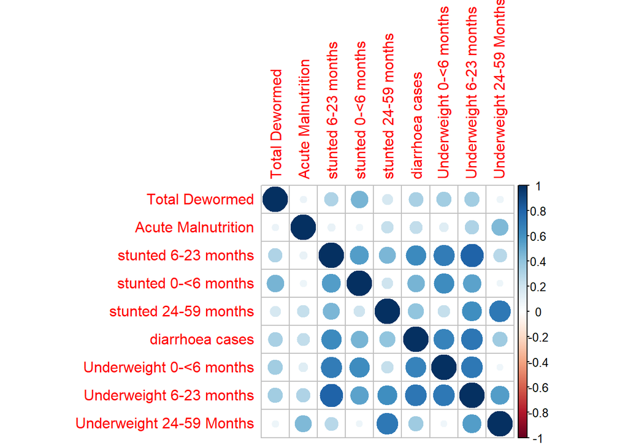

```r
library(corrplot)
corrplot(corl)
```

The two most highly correlated variables are “Underweight 6-23 months” and “stunted 6-23 months”, with a correlation coefficient of 0.80521446. The correlations between the variables vary by degree, but we have no two variables being inversely correlated.

##Plotting scatterplots for the variables-pairwise.

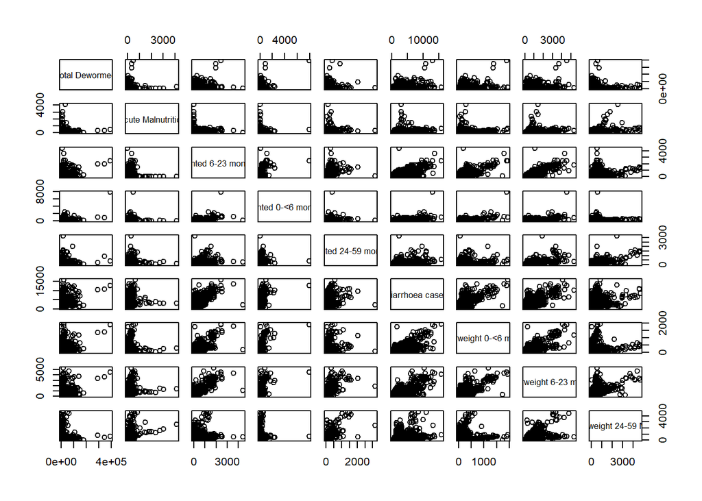

```r
pairs(data[,-c(1,2)])
```

The scatter plots further depict the relationships between the variables. It is evident that the variables have direct relationships with each other, albeit to varying degrees.

## Examining the distributions of the numeric variables

### Total Dewormed

```r
summary(data$`Total Dewormed`)
```

```
##    Min. 1st Qu.  Median    Mean 3rd Qu.    Max.
##      97    2454    4564   11458    8222  392800
```

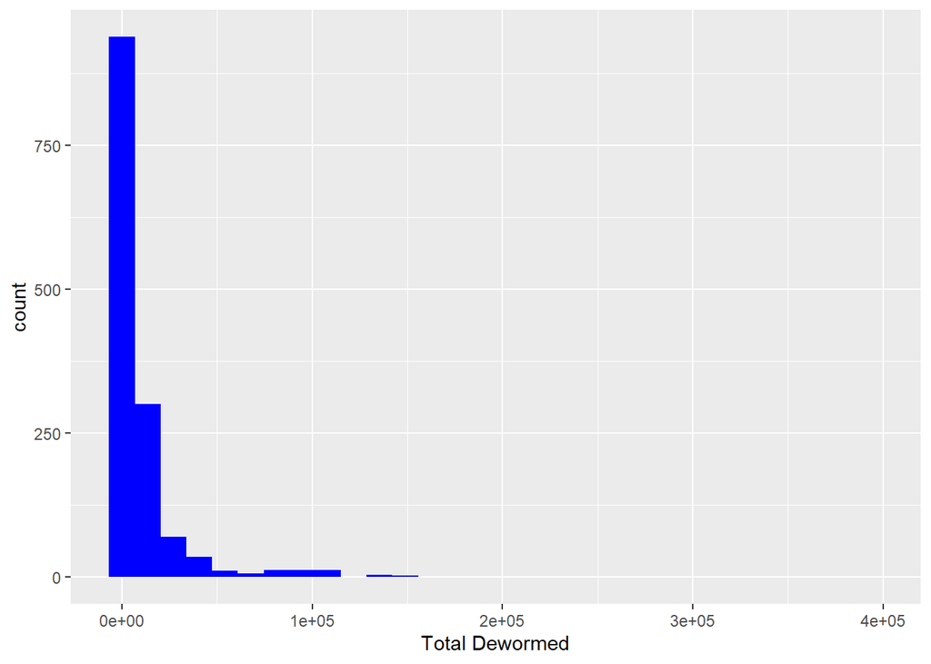

```r
ggplot(data,aes(x=`Total Dewormed`))+geom_histogram(fill="blue")
```

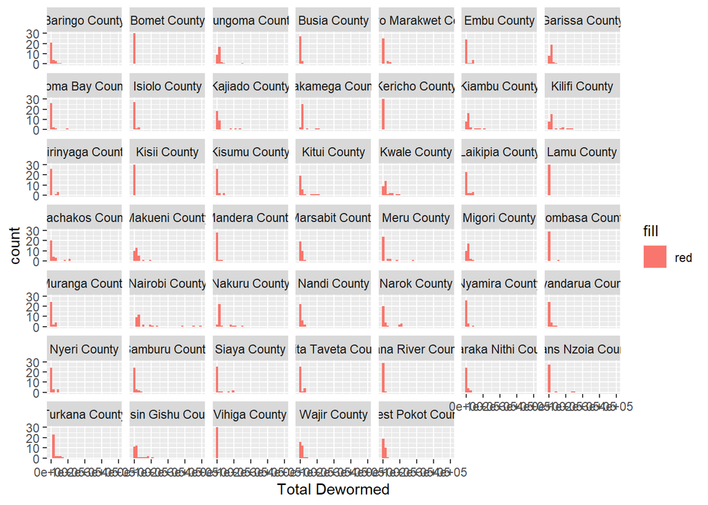

```r
ggplot(data,aes(x=`Total Dewormed`))+geom_histogram(aes(fill="red"))+facet_wrap(~county)
```

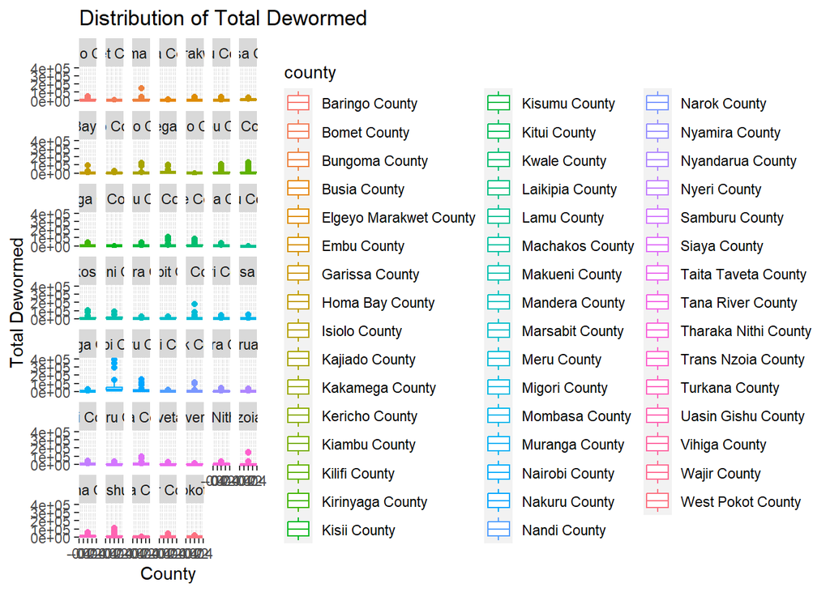

```r
ggplot(data, aes(y=`Total Dewormed`, color=county))+geom_boxplot()+labs(title="Distribution of Total Dewormed", x="County", y="Total Dewormed")+facet_wrap(~county)
```

The minimum entry for the total dewormed variable is 97, with a median of 4564, mean of 11458, and maximum of 392800. From the histograms, we can see that the total number of dewormed children is skewed to the right. The boxplots indicate that the numbers for “Total Dewormed” are largely concentrated in the relatively lower end of the spectrum, with very fer extreme outliers.

### Acute Malnutrition

```r
summary(data$`Acute Malnutrition`)
```

```
##    Min. 1st Qu.  Median    Mean 3rd Qu.    Max.    NA's
##     1.0    15.0    39.0   125.4   143.5  4123.0     355
```

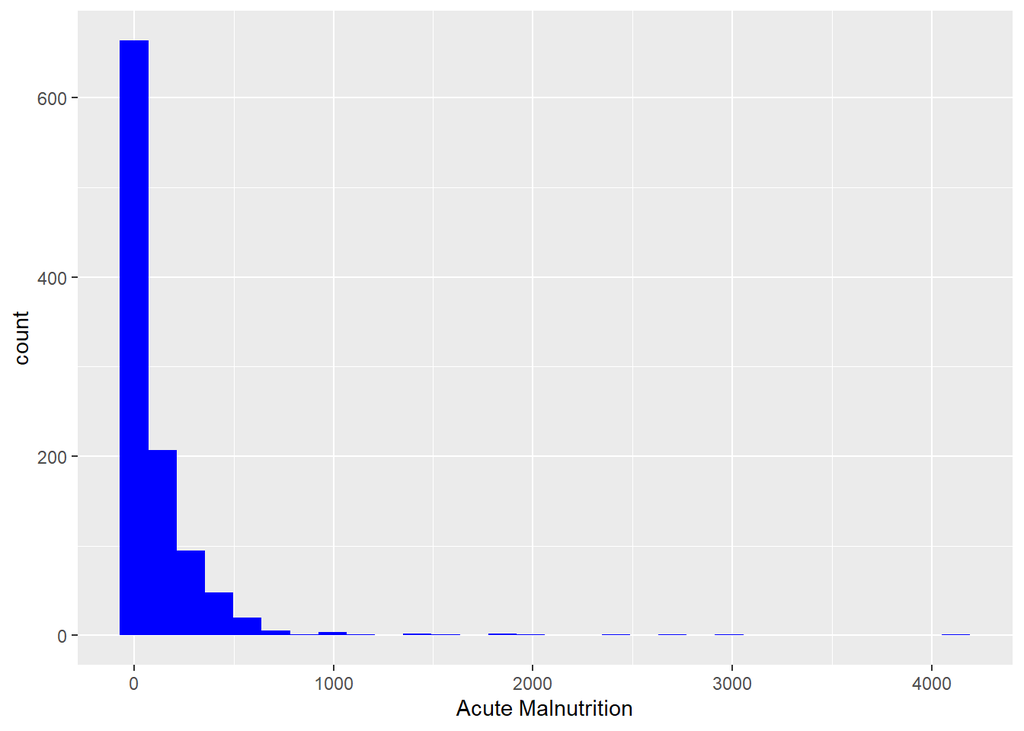

```r
ggplot(data,aes(x=`Acute Malnutrition`))+geom_histogram(fill="blue")
```

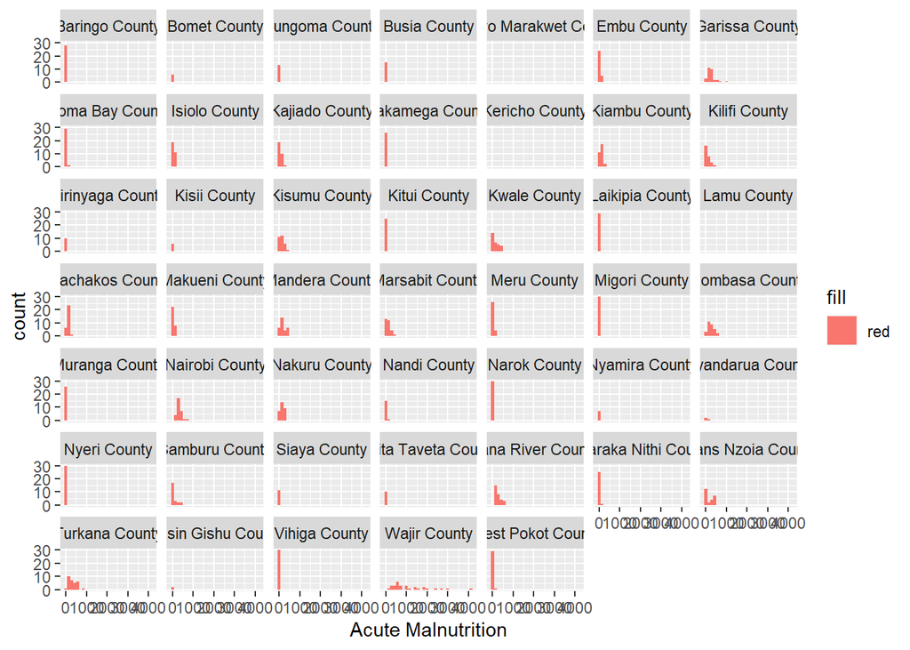

```r
ggplot(data,aes(x=`Acute Malnutrition`))+geom_histogram(aes(fill="red"))+facet_wrap(~county)
```

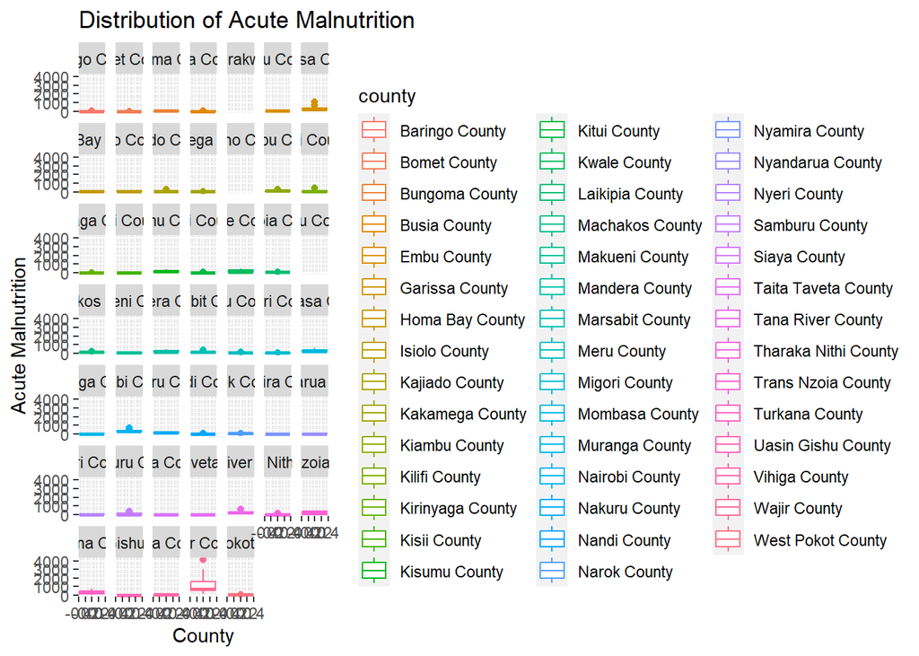

```r
ggplot(data, aes(y=`Acute Malnutrition`, color=county))+geom_boxplot()+labs(title="Distribution of Acute Malnutrition", x="County", y="Acute Malnutrition")+facet_wrap(~county)
```

The minimum entry for the acute malnutrition variable is 1, with a median of 39, mean of 125.4, and maximum of 4123. From the histograms, we can see that the total number of children with acute malnutrition is skewed to the right. The boxplots indicate that the numbers for “acute malnutrition” are largely concentrated in the relatively lower end of the spectrum, with very few extreme outliers.

### stunted 6-23 months

```r
summary(data$`stunted 6-23 months`)
```

```
##    Min. 1st Qu.  Median    Mean 3rd Qu.    Max.    NA's
##     1.0    69.5   159.0   280.2   328.5  4398.0      11
```

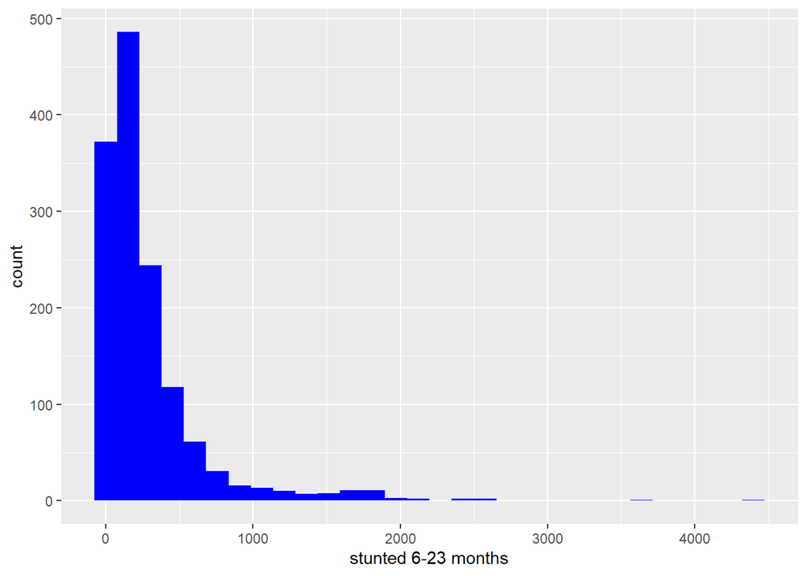

```r
ggplot(data,aes(x=`stunted 6-23 months`))+geom_histogram(fill="blue")
```

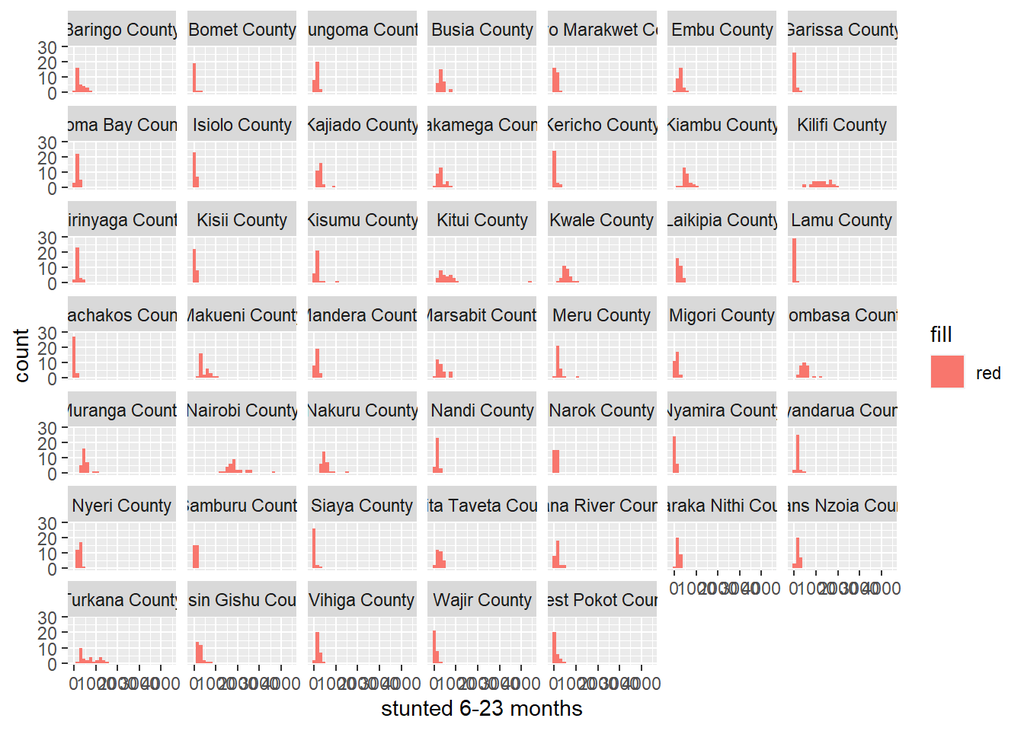

```r
ggplot(data,aes(x=`stunted 6-23 months`))+geom_histogram(aes(fill="red"))+facet_wrap(~county)
```

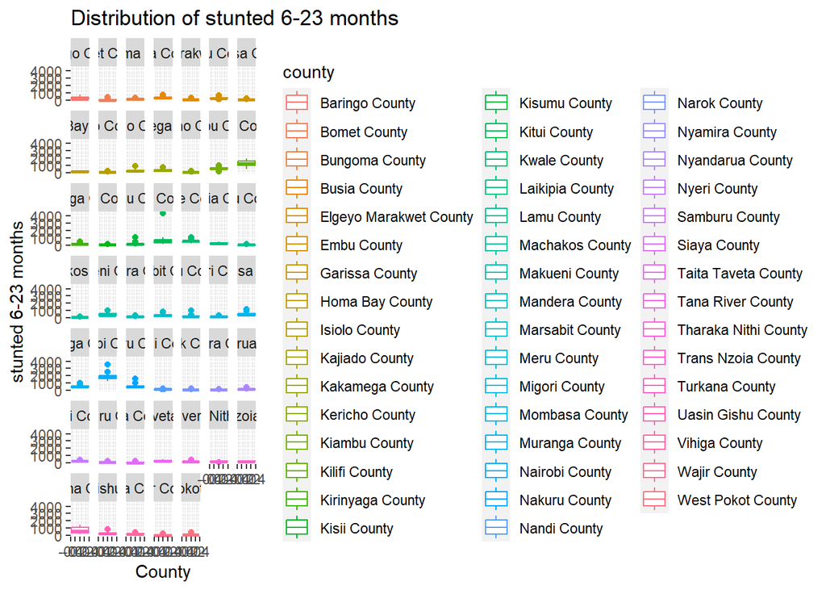

```r
ggplot(data, aes(y=`stunted 6-23 months`, color=county))+geom_boxplot()+labs(title="Distribution of stunted 6-23 months", x="County", y="stunted 6-23 months")+facet_wrap(~county)
```

The minimum entry for the stunted 6-23 months variable is 1, with a median of 159, mean of 280.2, and maximum of 4398. From the histograms, we can see that the total number of children with stunted growth between 6-23 months is skewed to the right. The boxplots indicate that the numbers for “stunted 6-23 months” are largely concentrated in the relatively lower end of the spectrum, with very few extreme outliers.

### stunted 0-<6 months

```r
summary(data$`stunted 0-<6 months`)
```

```
##    Min. 1st Qu.  Median    Mean 3rd Qu.    Max.    NA's
##     1.0    36.5    84.0   139.8   157.0  7900.0      19
```

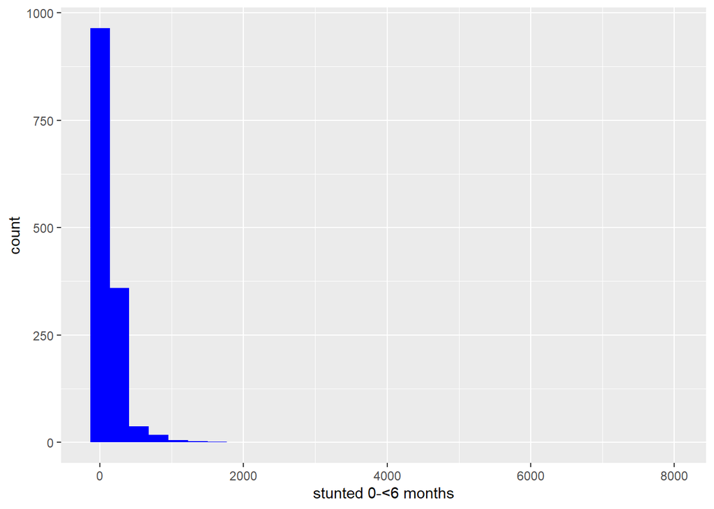

```r
ggplot(data,aes(x=`stunted 0-<6 months`))+geom_histogram(fill="blue")
```

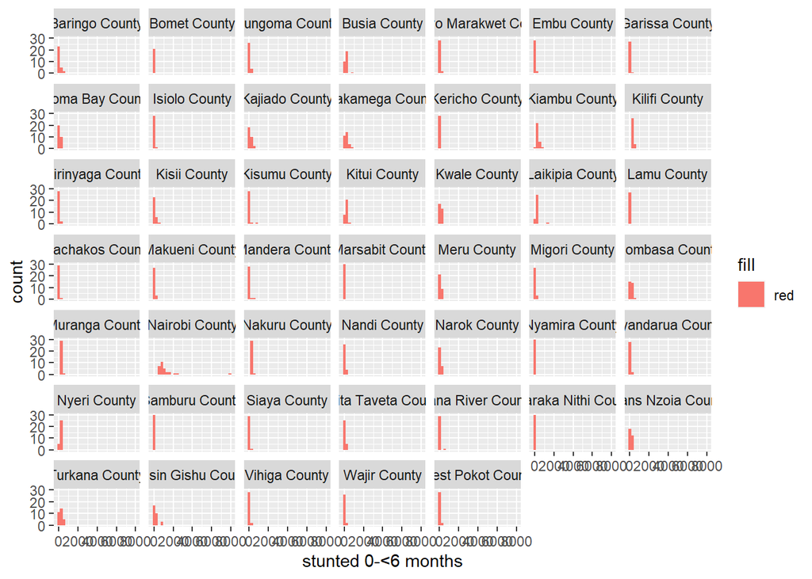

```r
ggplot(data,aes(x=`stunted 0-<6 months`))+geom_histogram(aes(fill="red"))+facet_wrap(~county)
```

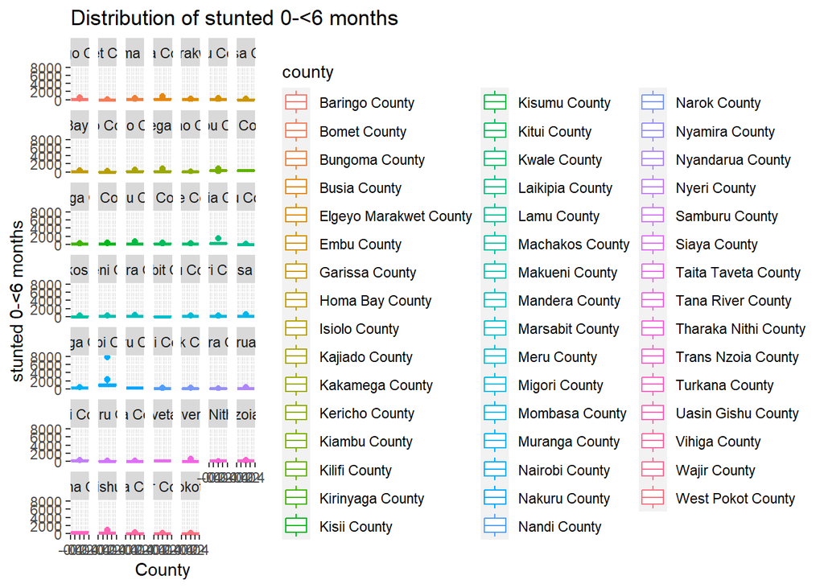

```r
ggplot(data, aes(y=`stunted 0-<6 months`, color=county))+geom_boxplot()+labs(title="Distribution of stunted 0-<6 months", x="County", y="stunted 0-<6 months")+facet_wrap(~county)
```

The minimum entry for the stunted 0-<6 months variable is 1, with a median of 84, mean of 139.8, and maximum of 7900. From the histograms, we can see that the total number of children with stunted growth between 0-<6 months is skewed to the right. The boxplots indicate that the numbers for “stunted 0-<6 months” are largely concentrated in the relatively lower end of the spectrum, with very few extreme outliers.

### stunted 24-59 months

```r
summary(data$`stunted 24-59 months`)
```

```
##    Min. 1st Qu.  Median    Mean 3rd Qu.    Max.    NA's
##     1.0    22.0    50.0   110.8   114.2  3169.0      14
```

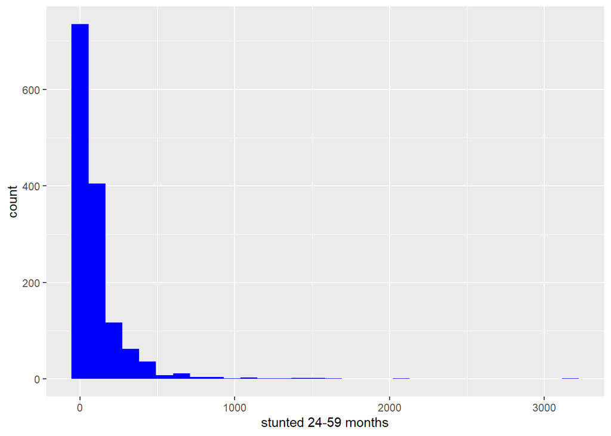

```r
ggplot(data,aes(x=`stunted 24-59 months`))+geom_histogram(fill="blue")
```

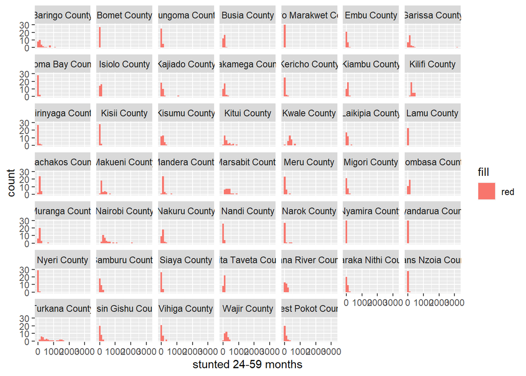

```r
ggplot(data,aes(x=`stunted 24-59 months`))+geom_histogram(aes(fill="red"))+facet_wrap(~county)
```

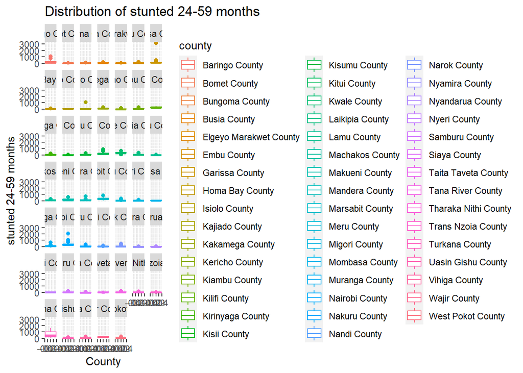

```r
ggplot(data, aes(y=`stunted 24-59 months`, color=county))+geom_boxplot()+labs(title="Distribution of stunted 24-59 months", x="County", y="stunted 24-59 months")+facet_wrap(~county)
```

The minimum entry for the stunted 24-59 months variable is 1, with a median of 50, mean of 110.8, and maximum of 3169. From the histograms, we can see that the total number of children with stunted growth between 24-59 months is skewed to the right. The boxplots indicate that the numbers for “stunted 24-59 months” are largely concentrated in the relatively lower end of the spectrum, with very few extreme outliers.

### diarrhoea cases

```r
summary(data$`diarrhoea cases`)
```

```
##    Min. 1st Qu.  Median    Mean 3rd Qu.    Max.
##     198    1464    2158    2813    3335   15795
```

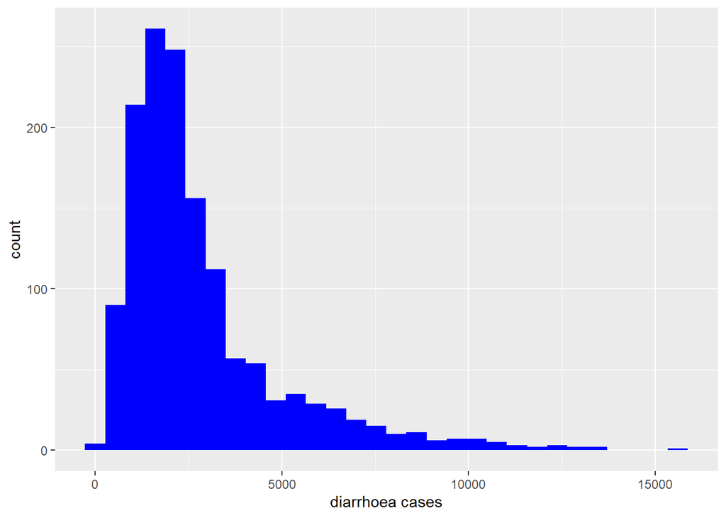

```r
ggplot(data,aes(x=`diarrhoea cases`))+geom_histogram(fill="blue")
```

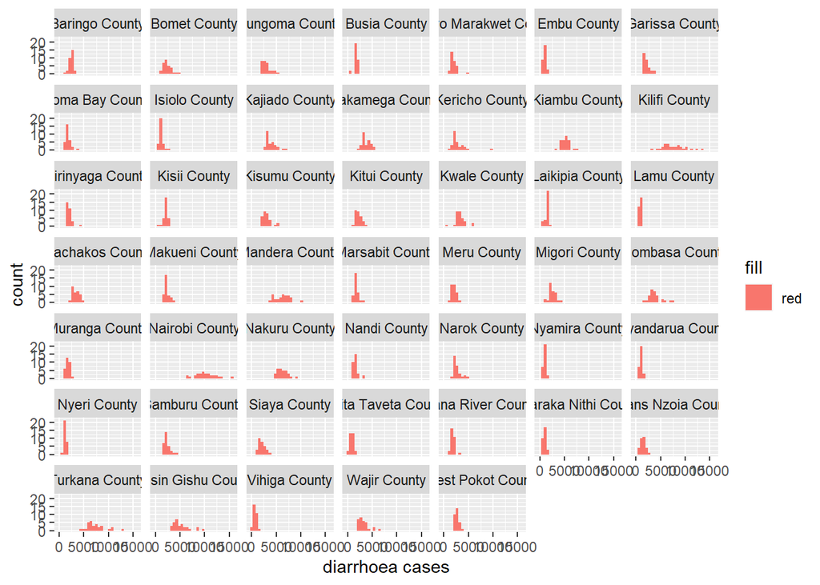

```r
ggplot(data,aes(x=`diarrhoea cases`))+geom_histogram(aes(fill="red"))+facet_wrap(~county)
```

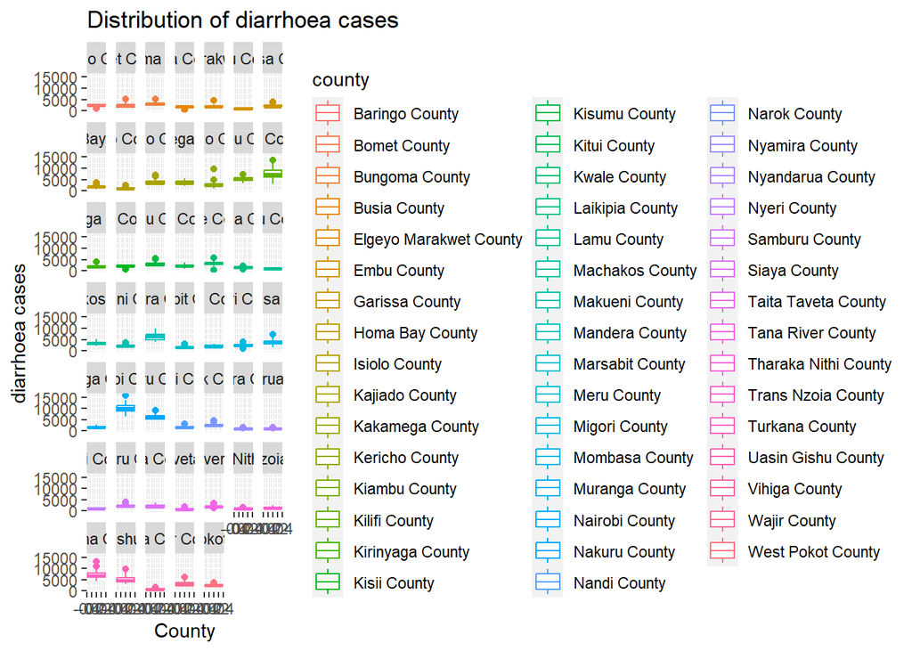

```r
ggplot(data, aes(y=`diarrhoea cases`, color=county))+geom_boxplot()+labs(title="Distribution of diarrhoea cases", x="County", y="diarrhoea cases")+facet_wrap(~county)
```

### Underweight 0-<6 months

```r
summary(data$`Underweight 0-<6 months`)
```

```
##    Min. 1st Qu.  Median    Mean 3rd Qu.    Max.
##     6.0    87.0   162.5   223.5   272.8  1937.0
```

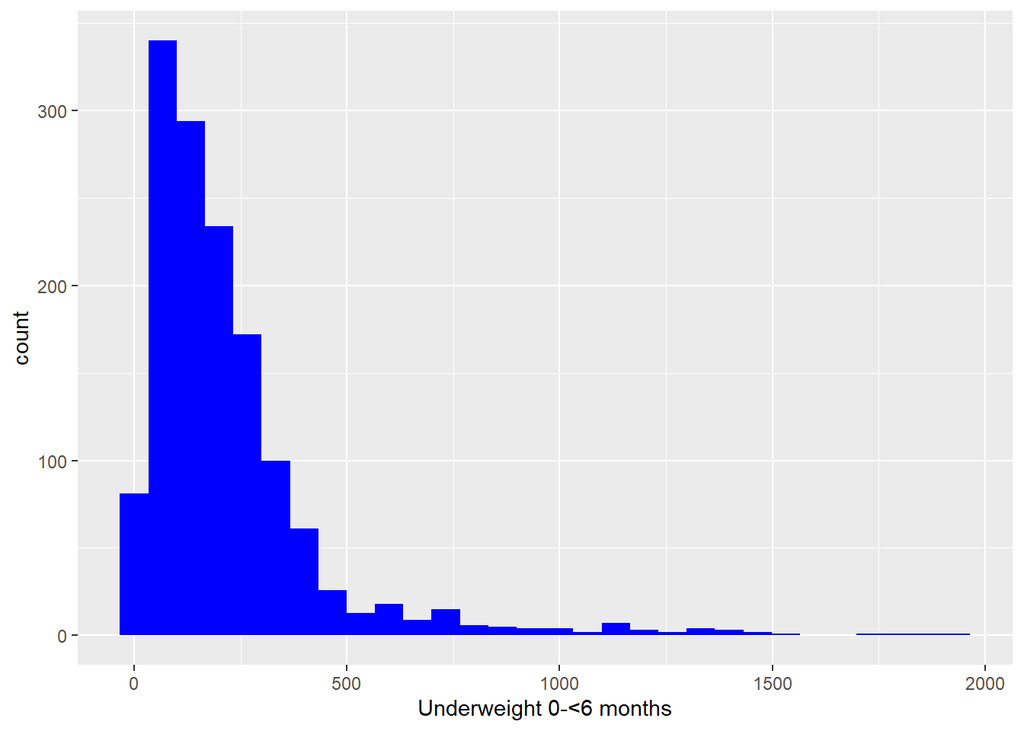

```r
ggplot(data,aes(x=`Underweight 0-<6 months`))+geom_histogram(fill="blue")
```

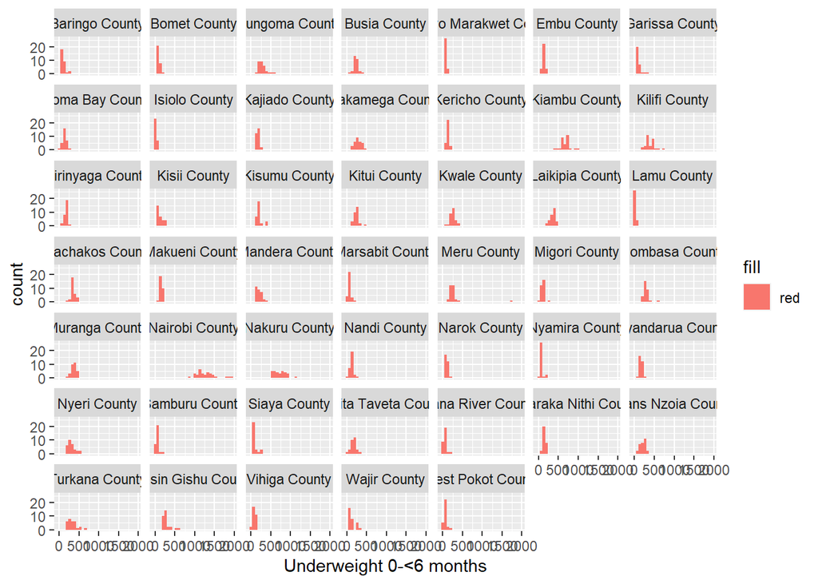

```r
ggplot(data,aes(x=`Underweight 0-<6 months`))+geom_histogram(aes(fill="red"))+facet_wrap(~county)
```

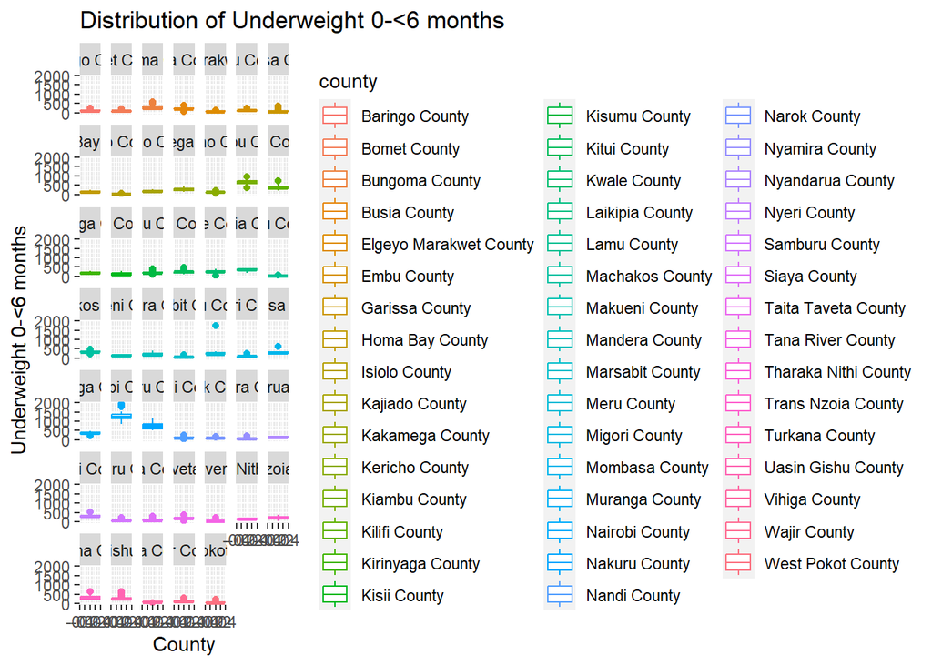

```r
ggplot(data, aes(y=`Underweight 0-<6 months`, color=county))+geom_boxplot()+labs(title="Distribution of Underweight 0-<6 months", x="County", y="Underweight 0-<6 months")+facet_wrap(~county)
```

The minimum entry for the Underweight 0-<6 months variable is 6, with a median of 162.5, mean of 223.5, and maximum of 1937. From the histograms, we can see that the total number of underweight children between 0-<6 months reported is skewed to the right. The boxplots indicate that the numbers for “Underweight 0-<6 months” are largely concentrated in the relatively lower end of the spectrum, with very few extreme outliers.

### Underweight 6-23 months

```r
summary(data$`Underweight 6-23 months`)
```

```
##    Min. 1st Qu.  Median    Mean 3rd Qu.    Max.
##    16.0   249.0   456.0   652.3   791.8  5348.0
```

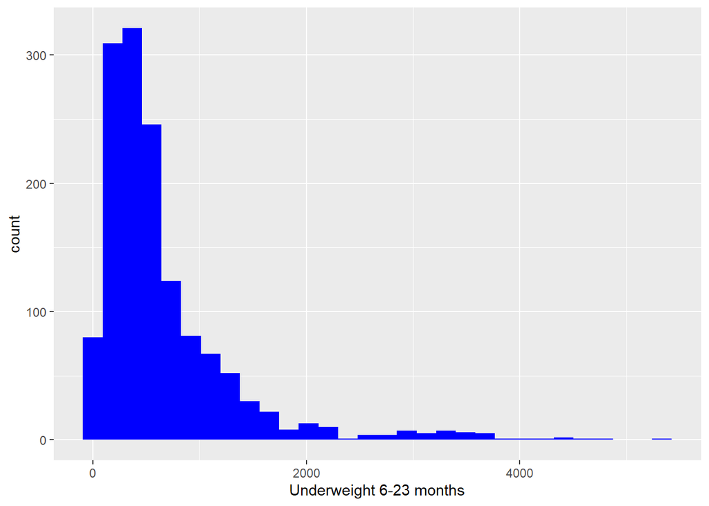

```r
ggplot(data,aes(x=`Underweight 6-23 months`))+geom_histogram(fill="blue")
```

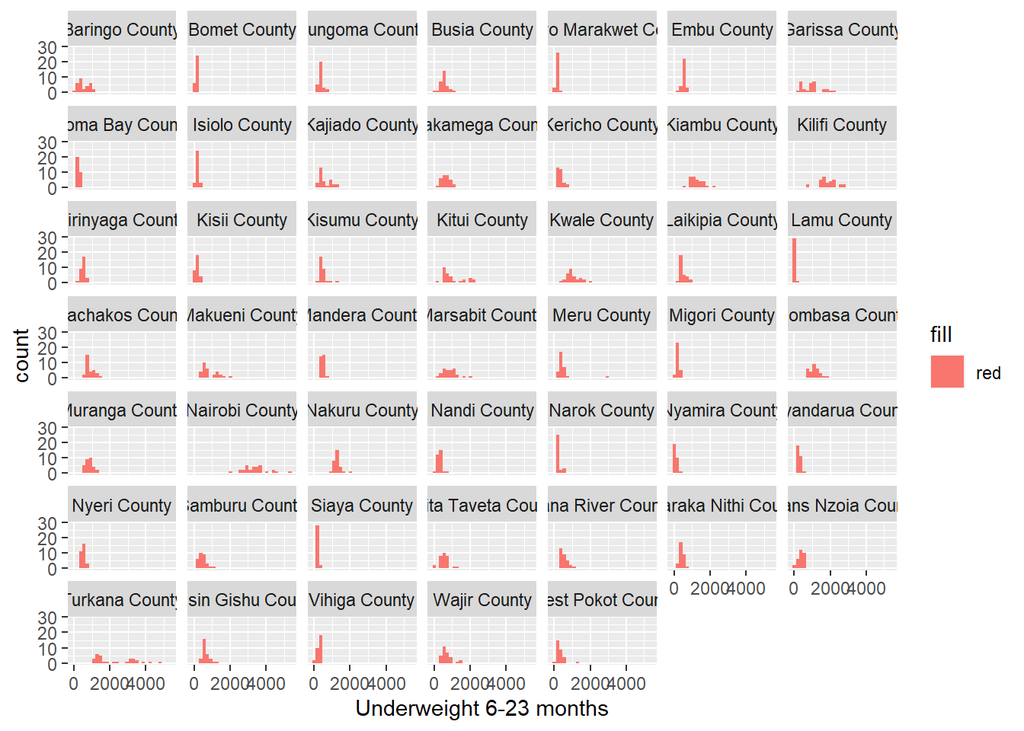

```r
ggplot(data,aes(x=`Underweight 6-23 months`))+geom_histogram(aes(fill="red"))+facet_wrap(~county)
```

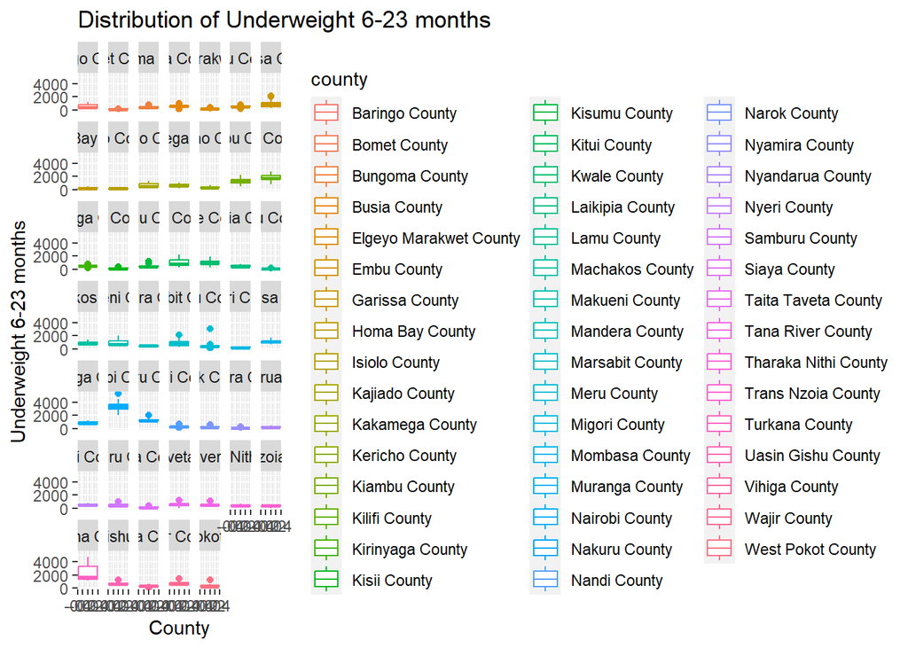

```r
ggplot(data, aes(y=`Underweight 6-23 months`, color=county))+geom_boxplot()+labs(title="Distribution of Underweight 6-23 months", x="County", y="Underweight 6-23 months")+facet_wrap(~county)
```

The minimum entry for the Underweight 6-23 months variable is 16, with a median of 456, mean of 652.3, and maximum of 5348. From the histograms, we can see that the total number of underweight children between 6-23 months reported is skewed to the right. The boxplots indicate that the numbers for “Underweight 6-23 months” are largely concentrated in the relatively lower end of the spectrum, with very few extreme outliers. Incidences in Naairobi and Turkana counties, however, seem to be differently distributed relative to other countries, with higher numbers.

### Underweight 24-59 Months

```r
summary(data$`Underweight 24-59 Months`)
```

```
##    Min. 1st Qu.  Median    Mean 3rd Qu.    Max.
##    1.00   51.25  120.50  305.74  311.00 4680.00
```

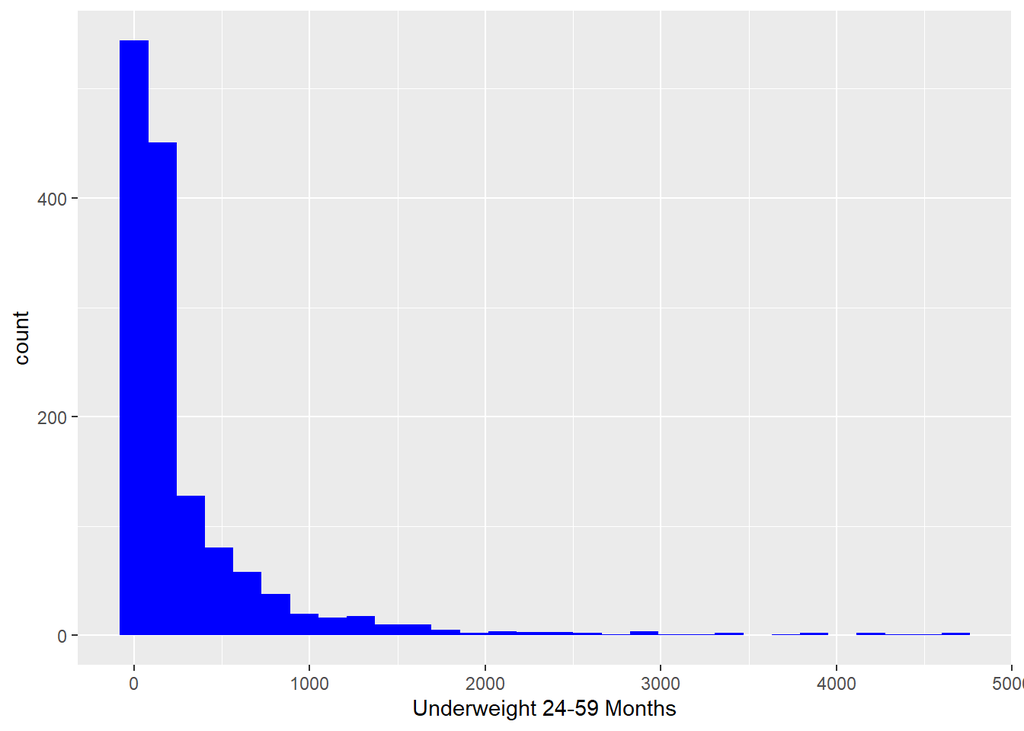

```r
ggplot(data,aes(x=`Underweight 24-59 Months`))+geom_histogram(fill="blue")
```

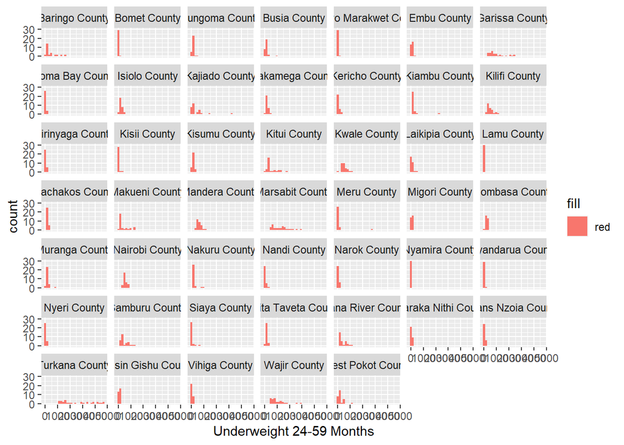

```r
ggplot(data,aes(x=`Underweight 24-59 Months`))+geom_histogram(aes(fill="red"))+facet_wrap(~county)
```

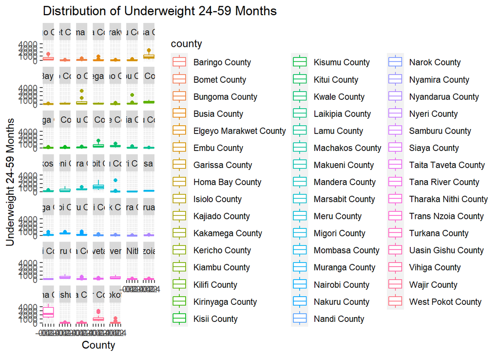

```r
ggplot(data, aes(y=`Underweight 24-59 Months`, color=county))+geom_boxplot()+labs(title="Distribution of Underweight 24-59 Months", x="County", y="Underweight 24-59 Months")+facet_wrap(~county)
```